# Step 2 — Plain-Language Plots

Raw-scale means for non-technical audiences

Nicole Cooper

2026-07-06

These plots use **raw, unstandardized scales** (not SD units) and show the **mean ± 1 SE** (the precision of each group’s estimated average — the same uncertainty basis as the technical analysis, just plotted on the item’s original scale). Asterisks mark conditions that differ significantly from Control, based on the condition regression. They’re meant for sharing with audiences who don’t need full model output — just “here’s what people said, and here’s what’s a real difference vs. not.”

## Self-relevance

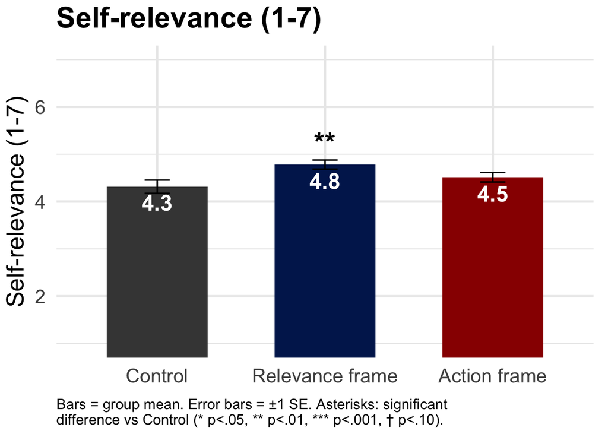

## Want to read more, share directly, share on social media

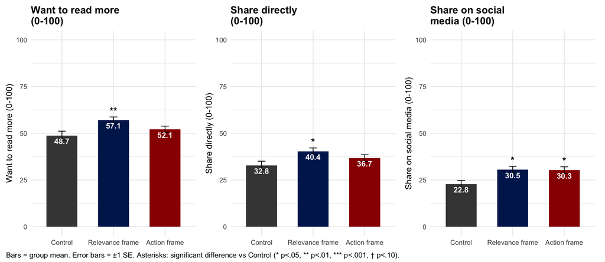

## Govt funding attitudes

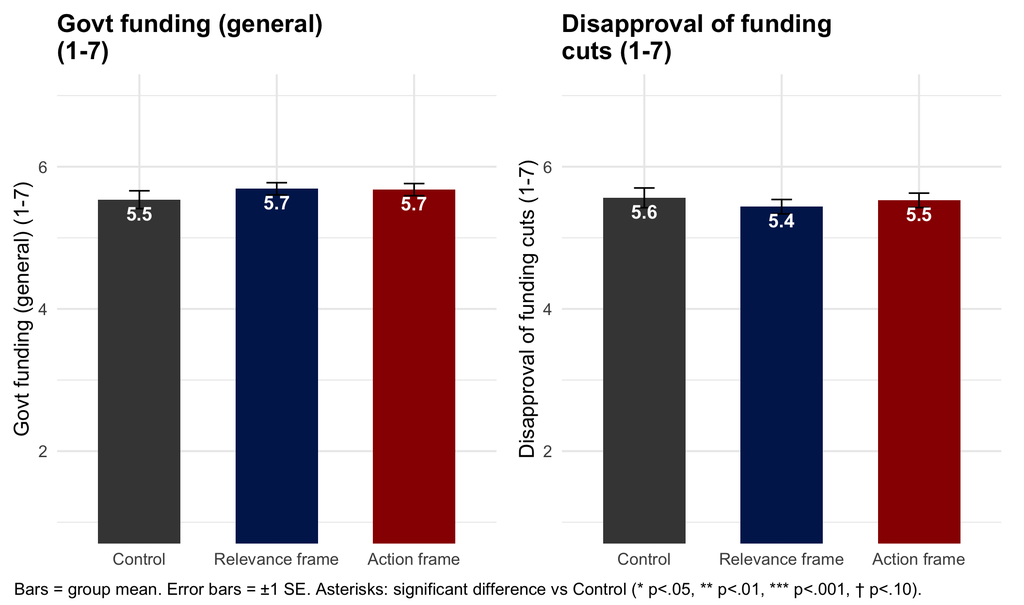

## Behavioral intentions

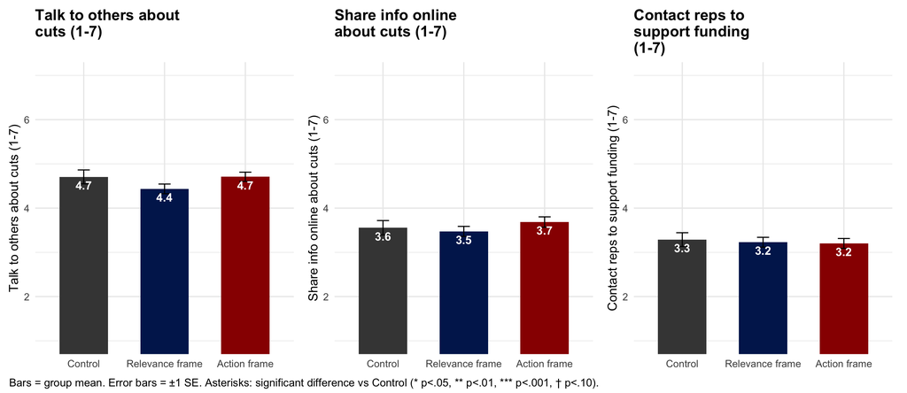

## Self-relevance → other outcomes

Pooled across all three conditions: does rating an article as more self-relevant go along with higher scores on these outcomes? Points show the simple Pearson correlation (not a per-condition breakdown); all five are significant, so no asterisks are shown.

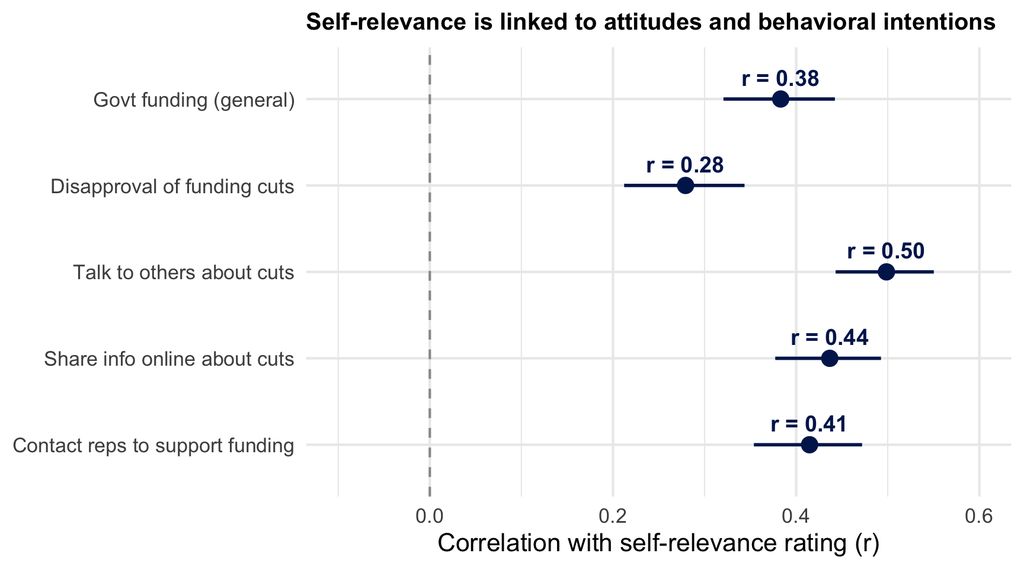